# IRT analysis report

November 25, 2026 | mirt 1.48 | mirtverse 0.6.0

## Summary

### Overview

- A graded model with 1 dimension was fitted to 392 respondents and 4 items (EM estimation).
- The estimation converged normally.

### Model fit

- Overall model fit is poor: C2 = 19.18, df = 2, RMSEA = 0.148, CFI = 0.910, SRMSR = 0.073.

### Reliability

- Marginal reliability is 0.67 (low).
- Scores are too imprecise for decisions about individuals; consider adding items or using the scores only for group-level summaries.

### Targeting

- The average item location is -0.99 and the average person score is 0.00, so the test is relatively easy for this group.
- Measurement is most precise around theta = -2.20 (information = 2.42, SE = 0.64).

### Items

- No items were flagged for low discrimination, extreme location, or misfit.

### Local dependence

- 1 item pair shows possible local dependence (Q3 exceeds the average of -0.19 by more than 0.2).
- Strongest: Comfort & Benefit (Q3 = 0.08).
- Check whether these items share a stimulus, wording, or content; consider a testlet or bifactor model.

### Person fit

- 4.8% of respondents have unusual response patterns (Zh < -1.96), which is within what chance alone would produce.

## Model

| Statistic | Value |
| --- | --- |
| nobs | 392 |
| nitems | 4 |
| nfact | 1 |
| itemtype | graded |
| npar | 16 |
| logLik | -1608.9 |
| AIC | 3249.7 |
| BIC | 3313.3 |
| SABIC | 3262.5 |
| converged | yes |
| method | EM |
| fit_stat | C2 |
| M2 | 19.179 |
| df | 2 |
| p.value | 0.000 |
| RMSEA | 0.148 |
| SRMSR | 0.073 |
| CFI | 0.910 |
| TLI | 0.730 |
| reliability | 0.669 |

## Items

Status uses the item health rules: red for misfit or low discrimination, amber for other flags, green otherwise.

| item | status | itemtype | N | mean | item_total_r | S_X2 | df | RMSEA | p.value | flag |
| --- | --- | --- | --- | --- | --- | --- | --- | --- | --- | --- |
| Comfort | green | graded | 392 | 3.120 | 0.352 | 4.774 | 6 | 0 | 0.573 |  |
| Work | green | graded | 392 | 2.722 | 0.332 | 8.756 | 9 | 0 | 0.460 |  |
| Future | green | graded | 392 | 2.990 | 0.488 | 7.543 | 8 | 0 | 0.479 |  |
| Benefit | green | graded | 392 | 2.837 | 0.363 | 9.928 | 11 | 0 | 0.537 |  |

### Item parameters

Parameterization: IRT (a, b, g, u).

| item | a | b1 | b2 | b3 |
| --- | --- | --- | --- | --- |
| Comfort | 1.042 | -4.669 | -2.534 | 1.407 |
| Work | 1.226 | -2.385 | -0.735 | 1.849 |
| Future | 2.293 | -2.282 | -0.965 | 0.856 |
| Benefit | 1.095 | -3.058 | -0.906 | 1.542 |

## Graphics

### Test information

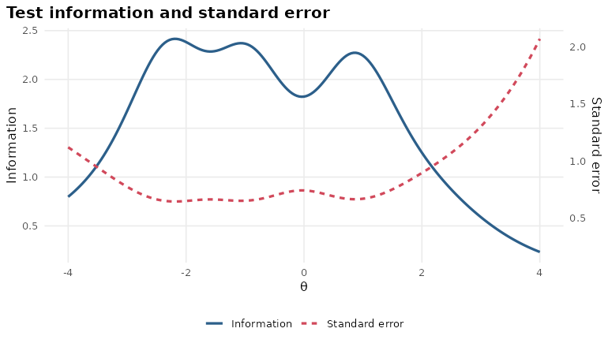

### Wright map

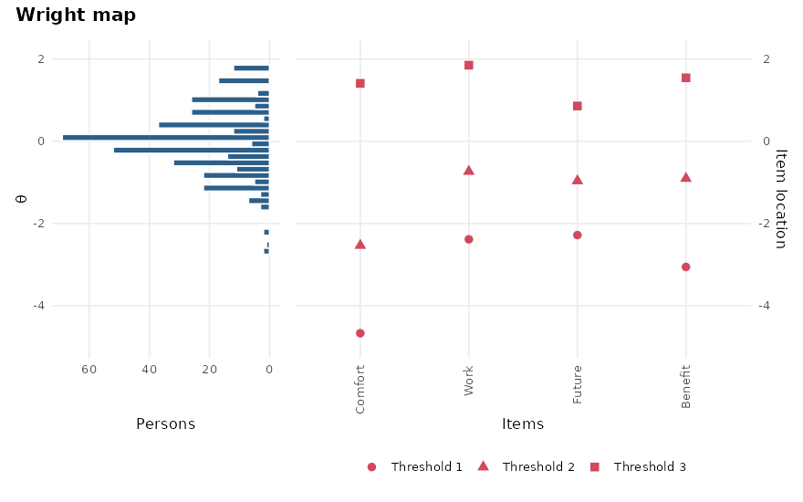

### Item characteristic curves

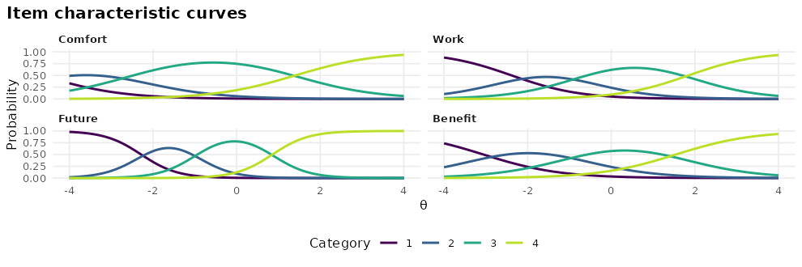

### Item fit

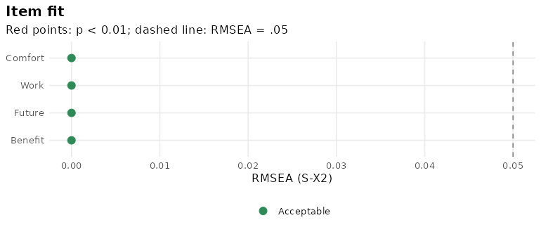

### Local dependence

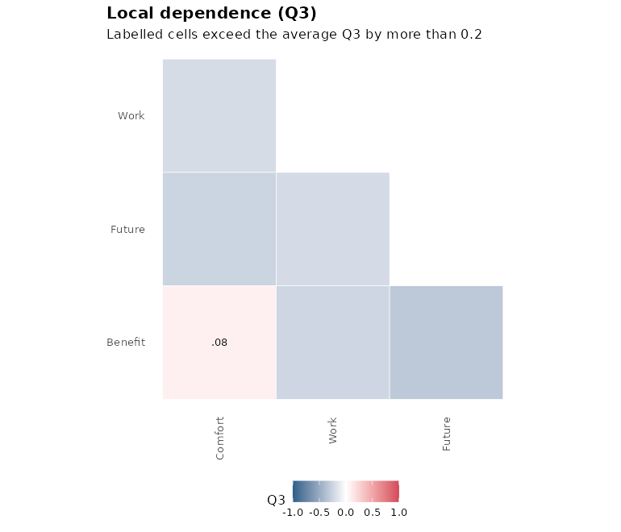

## Scores

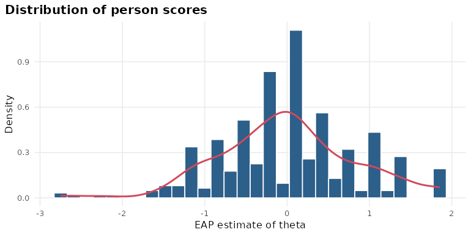

### Sum score conversion table

Expected a posteriori (EAP) ability for each total score, with its standard error. Observed and expected counts show how well the model reproduces the score distribution.

| Sum.Scores | F1 | SE_F1 | observed | expected |
| --- | --- | --- | --- | --- |
| 4 | -2.749 | 0.629 | 2 | 0.124 |
| 5 | -2.431 | 0.617 | 1 | 0.790 |
| 6 | -2.081 | 0.610 | 2 | 2.760 |
| 7 | -1.718 | 0.602 | 1 | 7.252 |
| 8 | -1.364 | 0.598 | 11 | 15.893 |
| 9 | -1.012 | 0.604 | 32 | 29.674 |
| 10 | -0.649 | 0.610 | 58 | 48.363 |
| 11 | -0.287 | 0.605 | 70 | 68.485 |
| 12 | 0.082 | 0.600 | 91 | 80.553 |
| 13 | 0.487 | 0.613 | 56 | 65.668 |
| 14 | 0.934 | 0.617 | 36 | 42.637 |
| 15 | 1.384 | 0.622 | 20 | 22.331 |
| 16 | 1.854 | 0.654 | 12 | 7.470 |

## Item health cards

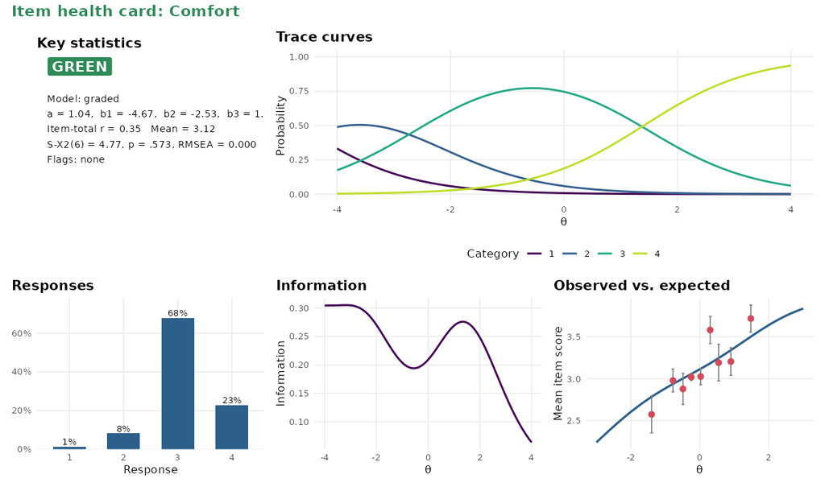

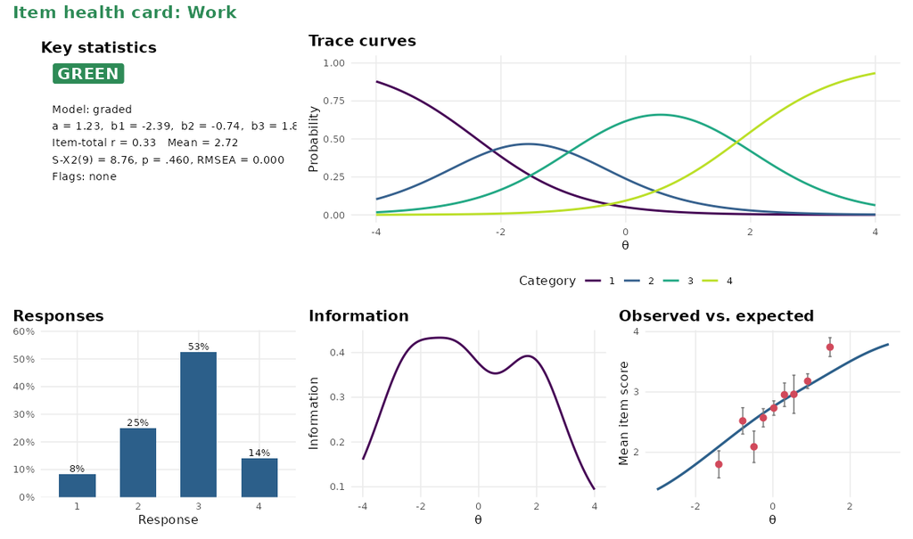

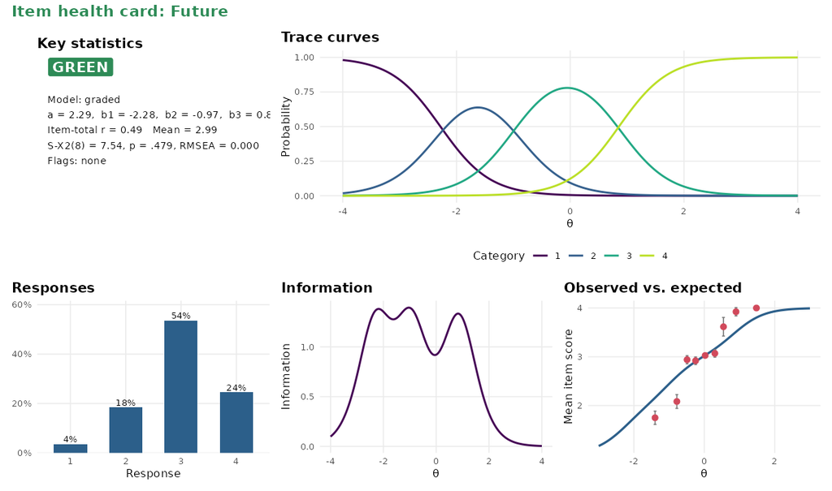

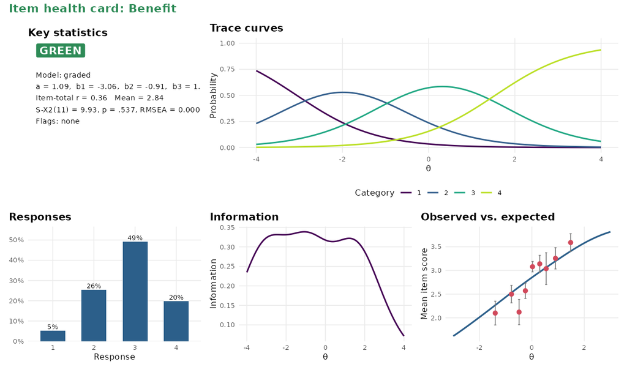

## Reproducibility

Run this code to reproduce the analysis:

```
library(mirtverse)
# data <- read.csv("your-data.csv")
mod <- mirt(data, 1, itemtype = "graded")
interpret(mod)
item_table(mod)
mv_report(mod, file = "mirtverse-report.html")
```

**Session information**

[output not shown]